# Parameter Tuning

Last time, I wrapped up my hit probability model testing by choosing a gradient boosting algorithm. Today, I'm going to do some grid search hyperparameter tuning to improve the model as much as I can. Since I'm relatively new to this, I'm going to just do one hyperparameter at a time.

I'll start by setting up a baseline model with all default settings. Like last time, there's a few things I have to do to the data first:

1) Remove any bunts from the dataset  
2) Map any non-hit outcome to 'out' (e.g. sacrifice fly, fielder's choice)  
3) One-hot encode batter handedness

```
/Users/JonahKrop/Documents/Projects/Baseball
```

```python
import pandas as pd
import numpy as np
import matplotlib.pyplot as plt
import seaborn as sns
import time as time

from sklearn.preprocessing import StandardScaler
from sklearn.model_selection import train_test_split, cross_validate, GridSearchCV
from sklearn.metrics import accuracy_score, log_loss, f1_score, roc_auc_score, make_scorer
from sklearn.ensemble import GradientBoostingClassifier
```

```python
# load in data
df_2016 = pd.read_csv('mlb_2016_adjusted.csv')
df_2017 = pd.read_csv('mlb_2017_adjusted.csv')
df_2018 = pd.read_csv('mlb_2018_adjusted.csv')
df_2019 = pd.read_csv('mlb_2019_adjusted.csv')

df = pd.concat([df_2016, df_2017, df_2018, df_2019], axis=0)

df = df.dropna(subset=['launch_speed', 'launch_angle', 'direction']).reset_index(drop=True)

# save some memory
del df_2016
del df_2017
del df_2018
del df_2019
```

```python
df_model = df.copy(deep=True)

# stand = handedness
cols = ['pitch_id', 'events', 'stand', 'launch_speed', 'launch_angle', 'direction']

# 1) drop bunts
df_model = df_model[cols][~df_model['events'].isin(
    ['sac_bunt', 'sac_bunt_double_play'])]

# 2) anything that's not a hit = out
df_model.loc[~df_model['events'].isin(
    ['single', 'double', 'triple', 'home_run']), 'events'] = 'out'

# 3) one-hot encode handedness
df_model = pd.concat([df_model, pd.get_dummies(df_model.stand)], axis=1)

# drop unecessary columns & rename to be a little clearer
df_model = df_model.drop(columns=['stand', 'L'])
df_model = df_model.rename(columns={'R': 'is_Right'})
```

I'll start with a baseline model to use for comparisons. I'm going to score using log loss, since I'm planning to use the probabilistic classifications from the model.

```python
s = df_model.sample(n=40000).reset_index(drop=True)

# scale and center numeric columns
to_scale = ['launch_speed', 'launch_angle', 'direction']
s[to_scale] = StandardScaler().fit_transform(s[to_scale])

X = s[to_scale + ['is_Right']]
y = s['events']
```

```python
model = GradientBoostingClassifier(random_state=0)

# cross-validate 5 times
res = cross_validate(model, X, y, cv=5, scoring='neg_log_loss')
results = pd.DataFrame(res)

print('baseline neg. log loss = %0.3f' % np.mean(results['test_score']))
```

```
baseline neg. log loss = -0.515
```

## Hyperparameter Tuning

Like I mentioned, I'm going to do one hyperparameter at a time using grid search, evaluating using log loss. There's many parameters that can be tuned, but I'm going to focus on a few important ones:

- `learning_rate`
- `n_estimators`
- `max_depth`
- `min_samples_split`
- `min_samples_leaf`

### Learning Rate & Number of Trees

I know I said I'd do one at a time, but learning rate and tree number go hand in hand. In gradient boosting, new trees are created and added to the model to explain errors from the previous step of the model. Learning rate governs the weight each tree is given in the model. A lower learning rate gives you a lower weight for each tree -- so more trees would be necessary to maintain a given level of performance for a lower learning rate. `sklearn` defaults are 0.1 for `learning_rate` and 100 for `n_estimators`.

```python
# parameters for grid search
grid = {'learning_rate': [0.2, 0.15, 0.1, 0.05, 0.01],
        'n_estimators': [50, 100, 200, 300, 400, 500]}

model = GradientBoostingClassifier(random_state=0)

res1 = GridSearchCV(model, grid, scoring='neg_log_loss',
                    return_train_score=True, n_jobs=4).fit(X, y)
results1 = pd.DataFrame(res1.cv_results_)

print('best learning rate = %s' % res1.best_params_['learning_rate'])
print('best number of trees = %s' % res1.best_params_['n_estimators'])
print('log loss with optimal parameters: %0.3f' % res1.best_score_)
```

```
best learning rate = 0.05
best number of trees = 500
log loss with optimal parameters: -0.501
```

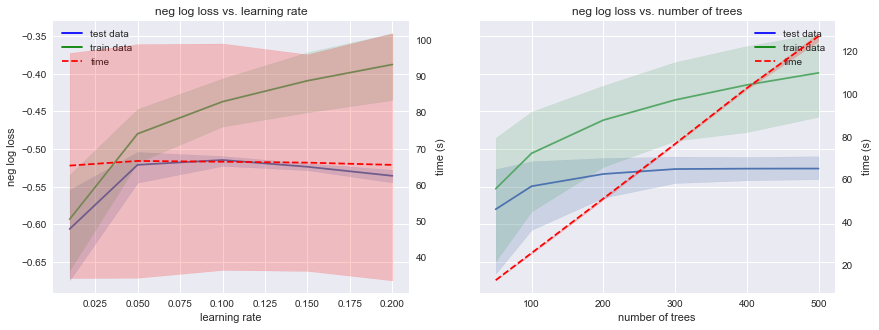

From the grid search, the model is optimized with learning rate = 0.05 and number of trees = 500. The learning rate plot shows the start of some overfitting past 0.1.

Even though the grid search recommended 500 trees, I'm going to use 300 instead. The additional trees offer fairly marginal improvement to the model while increasing runtime, which doesn't seem like a worthwhile tradeoff, especially since I'm going to eventually need to make predictions for around 500k data points. For reference, here's the top 5 parameters by log loss. Using 300 only reduces the log loss score by 0.004.

|  | params | mean_test_score | rank_test_score | mean_fit_time |
| --- | --- | --- | --- | --- |
| 23 | {'learning_rate': 0.05, 'n_estimators': 500} | -0.500862 | 1 | 128.706448 |
| 22 | {'learning_rate': 0.05, 'n_estimators': 400} | -0.502516 | 2 | 103.471764 |
| 21 | {'learning_rate': 0.05, 'n_estimators': 300} | -0.504786 | 3 | 77.365677 |
| 15 | {'learning_rate': 0.1, 'n_estimators': 300} | -0.507808 | 4 | 76.466850 |
| 14 | {'learning_rate': 0.1, 'n_estimators': 200} | -0.508805 | 5 | 51.106293 |

## Max Tree Depth

Max tree depth controls the number of nodes allowed for a tree. `sklearn` defaults this to 3, so I'll start around there and go as high as around 15.

```python
# set new params to test
grid = {'max_depth': [2, 4, 6, 10, 15]}

# this time, use ideal learning rate and num. trees
model = GradientBoostingClassifier(
    random_state=0,
    learning_rate=0.05,
    n_estimators=300
)

res2 = GridSearchCV(model, grid, scoring='neg_log_loss',
                    return_train_score=True,
                    n_jobs=4).fit(X, y)
results2 = pd.DataFrame(res2.cv_results_)

print('best max_depth = %s' % res2.best_params_['max_depth'])
print('log loss with optimal parameters: %0.3f' % res2.best_score_)
```

```
best max_depth = 4
log loss with optimal parameters: -0.497
```

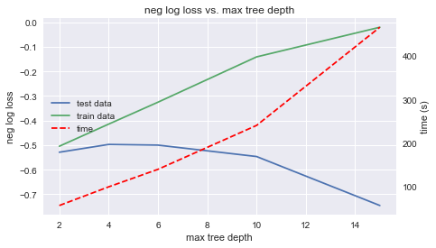

Similar improvement here as with tuning learning rate and number of trees. Larger max depth makes a real difference for overfitting -- training error heads to 0 at a max depth past 10 while testing error takes a nosedive.

### Min samples split

`min_samples_split` governs the number of samples of data needed to split a node into leafs. The `sklearn` default is 2. I have a pretty large dataset, so this can get large -- in some previous runs, I got an optimal number of samples of as high as 500. However, since at least one of my possible outcomes (triples) are fairly uncommon, I don't want the model to gloss over them by requiring too many samples to split a node, so I'm going to force this to be smaller.

```python
# set new params to test
grid = {'min_samples_split': [2, 4, 6, 10, 15]}

# this time, use ideal learning rate and num. trees
model = GradientBoostingClassifier(
    random_state=0,
    learning_rate=0.05,
    n_estimators=300,
    max_depth=4
)

res3 = GridSearchCV(model, grid, scoring='neg_log_loss',
                    return_train_score=True,
                    n_jobs=4,
                    ).fit(X, y)
results3 = pd.DataFrame(res3.cv_results_)

print('best min_samples_split = %s' % res3.best_params_['min_samples_split'])
print('log loss with optimal parameters: %0.3f' % res3.best_score_)
```

```
best min_samples_split = 4
log loss with optimal parameters: -0.497
```

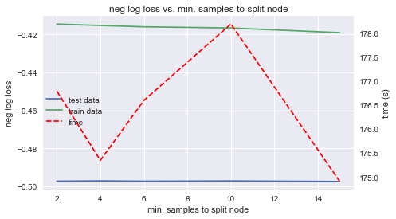

Ideal `min_samples_split` is set at 4. Overall, it doesn't look like it has a significant impact on log loss.

### Min samples leaf

Finally, we have `min_samples_leaf`. `min_samples_leaf` is similar to `min_samples_split`, requiring a minimum number of samples to create a leaf. The `sklearn` default is 1.

```python
# set new params to test
grid = {'min_samples_leaf': [2, 4, 6, 10, 15]}

# this time, use ideal learning rate and num. trees
model = GradientBoostingClassifier(
    random_state=0,
    learning_rate=0.05,
    n_estimators=300,
    max_depth=4,
    min_samples_split=4
)

res4 = GridSearchCV(model, grid, scoring='neg_log_loss',
                    return_train_score=True,
                    n_jobs=4).fit(X, y)
results4 = pd.DataFrame(res4.cv_results_)

print('best min_samples_leaf = %s' % res4.best_params_['min_samples_leaf'])
print('log loss with optimal parameters: %0.3f' % res4.best_score_)
```

```
best min_samples_leaf = 10
log loss with optimal parameters: -0.495
```

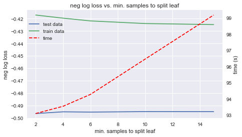

Adjusting `min_samples_leaf` looks pretty similar to `min_samples_split`, which isn't too surprising. Leafs are just nodes that have no additional nodes coming off them -- they make a classification instead of passing to another node.

### Tuning Summary

Successfully completed hyperparameter tuning! I didn't get a massive improvement in log loss (-0.515 to -0.495), but I'm still happy with the results. Here's the ultimate optimal parameters:

- learning rate = 0.05
- number of trees = 300
- max tree depth = 4
- min samples to split node = 4
- min samples to split leaf = 10